** Pbulicado o artigo em: https://rpubs.com/Luiz96/597367

# Modelos ml aplicado a séries temporais

Este é uma pequena aplicação de modelos de machine learning aplicado a um banco de dados de séries temporais. Os dados foram disponibilizados pelo livro Análise de Séries Temporais, de Pedro A. Moretin. Este mesmo está disponível como objeto de estudo no link : https://www.kaggle.com/mvsfnig/time-series-pam/version/6.

```r
# Carregando dados
data<- readr::read_csv("a6_poluicao.csv")
head(data)
```

| DATA | RES65 | PM10 | so2 | co | o3 | no2 |
| --- | --- | --- | --- | --- | --- | --- |
| 1997-01-01 | 11 | 36841 | 11326.0000 | 1.7133 | 68952.00 | 42535.00 |
| 1997-01-02 | 3 | 33634 | 16284.0000 | 1.6083 | 52.48 | 57.02 |
| 1997-01-03 | 11 | 35319 | 17.2100 | 1.8983 | 45.18 | 61838.00 |
| 1997-01-04 | 8 | 29742 | 16.0025 | 1675.0000 | 117338.00 | 78.51 |
| 1997-01-05 | 11 | 43343 | 21.3000 | 2012.0000 | 156.02 | 82008.00 |
| 1997-01-06 | 11 | 43787 | 26735.0000 | 2458.0000 | 126133.00 | 135.51 |

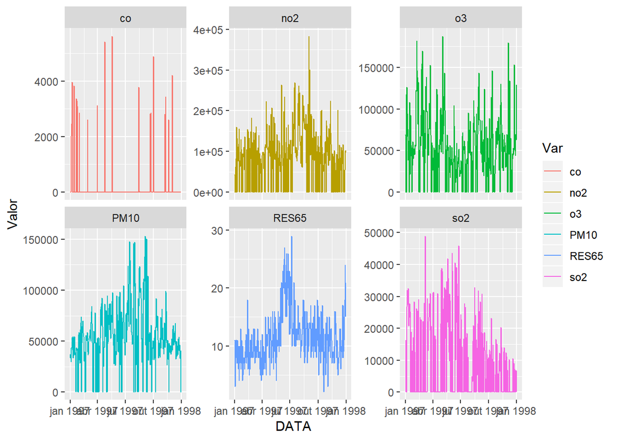

```r
data %>% gather(Var,Valor,-DATA) %>%  ggplot(aes(x = DATA,y =Valor, color = Var)) +
  geom_line() +
  facet_wrap(~Var, scales = "free_y")
```

```r
# Filtrando uma categoria
data_o3<- data %>% select(data=DATA,Qtd_o3 = o3)
```

Séries A6 (Poluição): Emissão diária de poluentes na cidade de São Paulo, de 1 de janeiro de 31 de dezembro de 1997. CO - gás carbônico. Os dados foram coletados diariamente, por tanto teremos 365 registros para a quantidade de O3 na cidade de São Paulo

```r
library(dplyr)
library(ggplot2)
library(tidyverse)
# Filtrando uma categoria
data_o3 %>% summary()
```

```
##       data                Qtd_o3
##  Min.   :1997-01-01   Min.   :    14.33
##  1st Qu.:1997-04-02   1st Qu.: 31052.00
##  Median :1997-07-02   Median : 50825.00
##  Mean   :1997-07-02   Mean   : 54837.83
##  3rd Qu.:1997-10-01   3rd Qu.: 73994.00
##  Max.   :1997-12-31   Max.   :187628.00
```

# Divisão de treinamento e teste

Como o objetivo de comparar modelos para uma melhor previsão do o3, vamos dividir a base de dados em treinamento e teste.

```r
data_o3_train<-
  data_o3 %>%
    mutate(week = wday(data,label = T)# %>% as.factor()
                             ,Month = month(data,label = T) #%>% as.factor()
                             , Day = day(data)) %>%
      filter(Month <'set')
data_o3_test<-
  data_o3 %>%
    mutate(week = wday(data,label = T)# %>% as.factor()
                                 ,Month = month(data,label = T) #%>% as.factor()
                                 , Day = day(data)) %>%
      filter(Month >='set')
data_future<- expand.grid(data = max(data_o3$data)+1:90) %>% as.data.frame() %>%
  mutate(week = wday(data,label = T),
         Month = month(data,label = T), #%>% as.factor()
         Day = day(data))
```

Estamos aqui criando o data_future, onde estaremos utilizando como variavel os dias, dias da semana e mês.

# Analise Descritiva

Aqui exploramos se existe algum padrão a nivel de mês, semana e ate mesmo o mês/semana. Para podermos visualizar de uma forma mais rapida se existe tal padrão, foi feito os boxplots desses niveis, juntamente com o intervalo de confiança considerentao o alpha de 5%.

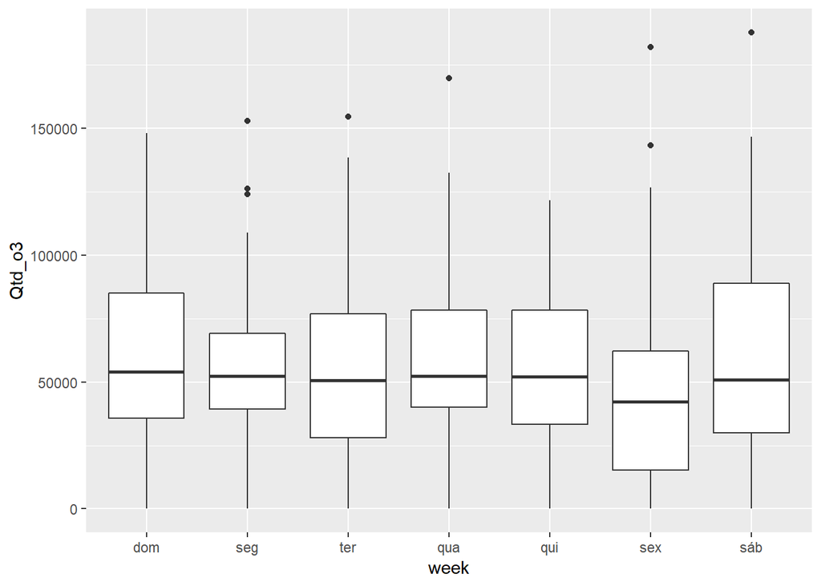

```r
# Analise por semana

data_o3_train %>% ggplot(aes(x=week,Qtd_o3)) + geom_boxplot()
```

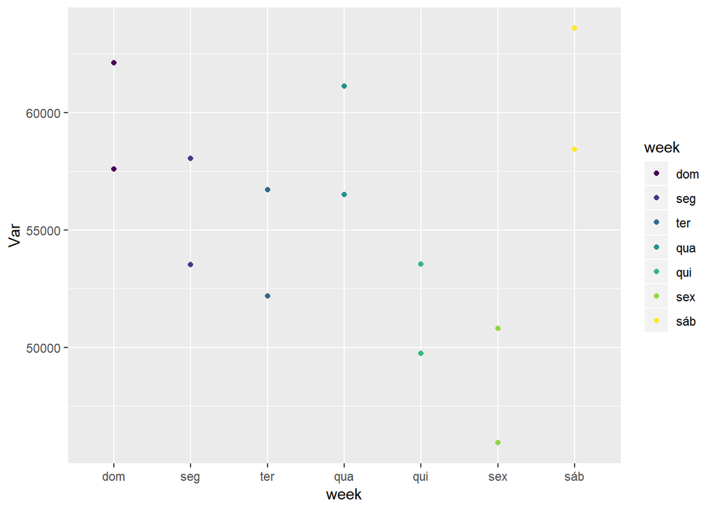

```r
data_o3_train %>%
  group_by(week) %>%
  summarise(Media = mean(Qtd_o3)
            ,Maximo = max(Qtd_o3)
            ,Minimo = min(Qtd_o3)
            ,Desvio = sd(Qtd_o3)
            ,N = n()
            ,ic2 = Media - 1.96*Desvio/N
            ,ic1 = Media + 1.96*Desvio/N) %>% select(week,ic1,ic2) %>%
  gather(Ics,Var,-week) %>% ggplot(aes(week,Var,col = week))+geom_point()
```

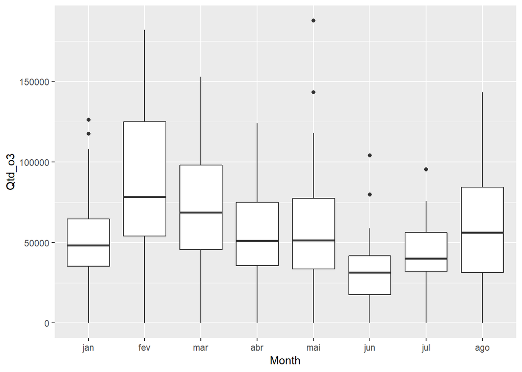

```r
#Analise por mes----

data_o3_train %>% ggplot(aes(x=Month,Qtd_o3)) + geom_boxplot()
```

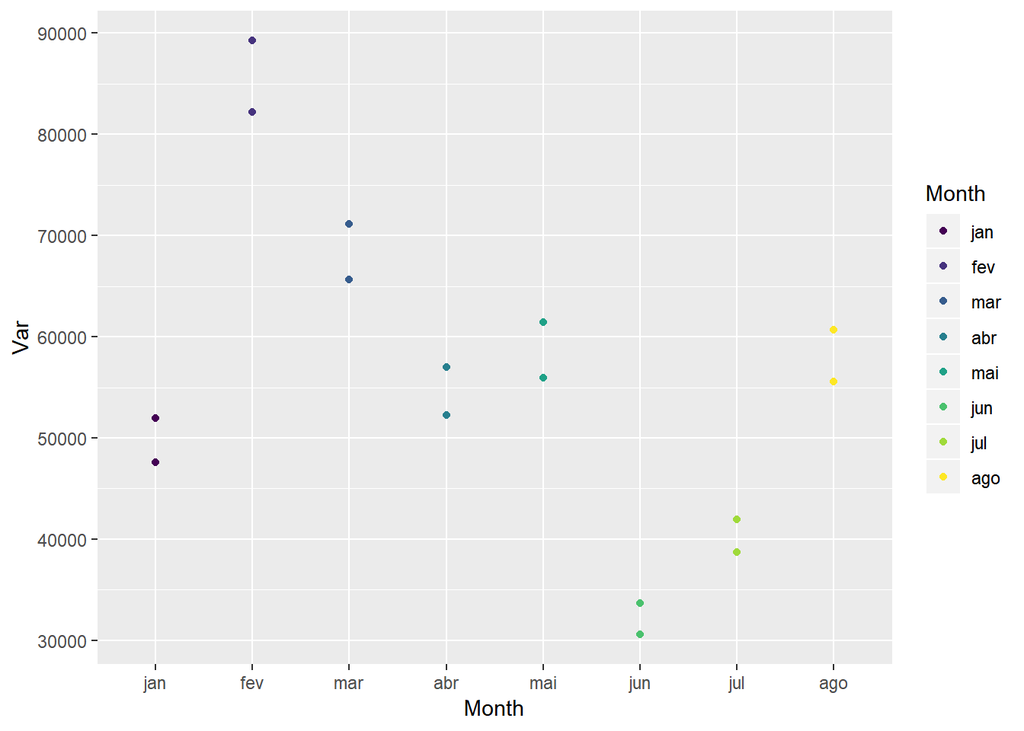

```r
data_o3_train %>%
  group_by(Month) %>%
  summarise(Media = mean(Qtd_o3)
            ,Maximo = max(Qtd_o3)
            ,Minimo = min(Qtd_o3)
            ,Desvio = sd(Qtd_o3)
            ,N = n()
            ,ic2 = Media - 1.96*Desvio/N
            ,ic1 = Media + 1.96*Desvio/N) %>% select(Month,ic1,ic2) %>%
  gather(Ics,Var,-Month) %>% ggplot(aes(Month,Var,col = Month))+geom_point()
```

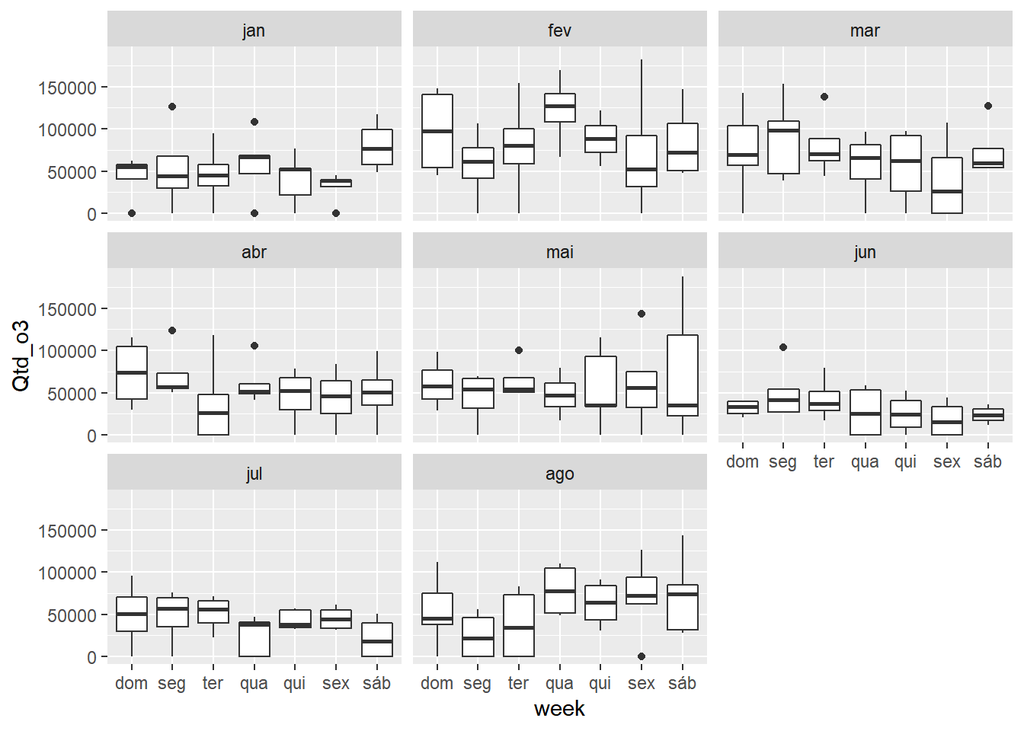

```r
#-Analise mes/semana----

data_o3_train %>% ggplot(aes(x=week,Qtd_o3)) + geom_boxplot() + facet_wrap(~Month)
```

```r
data_o3_train %>%
  group_by(Month,week) %>%
    summarise(Media = mean(Qtd_o3)
             ,Maximo = max(Qtd_o3)
             ,Minimo = min(Qtd_o3)
             ,Desvio = sd(Qtd_o3)
             ,N = n()
             ,ic2 = Media - 1.96*Desvio/N
             ,ic1 = Media + 1.96*Desvio/N)
```

| Month | week | Media | Maximo | Minimo | Desvio | N | ic2 | ic1 |
| --- | --- | --- | --- | --- | --- | --- | --- | --- |
| jan | dom | 43229.00 | 61858 | 156.02 | 28895.606 | 4 | 29070.158 | 57387.85 |
| jan | seg | 53692.14 | 126133 | 50.54 | 52706.654 | 4 | 27865.875 | 79518.40 |
| jan | ter | 46105.15 | 94912 | 64.60 | 38761.732 | 4 | 27111.902 | 65098.40 |
| jan | qua | 58239.78 | 107893 | 43.88 | 39276.048 | 5 | 42843.565 | 73635.99 |
| jan | qui | 40765.30 | 76266 | 52.48 | 29918.895 | 5 | 29037.089 | 52493.50 |
| jan | sex | 31143.64 | 45136 | 45.18 | 18000.820 | 5 | 24087.314 | 38199.96 |
| jan | sáb | 79835.75 | 117338 | 48515.00 | 31148.418 | 4 | 64573.025 | 95098.47 |
| fev | dom | 97099.25 | 147915 | 45555.00 | 53464.033 | 4 | 70901.874 | 123296.63 |
| fev | seg | 57277.22 | 105984 | 60.87 | 43843.044 | 4 | 35794.126 | 78760.31 |
| fev | ter | 78643.70 | 154487 | 34.80 | 63087.454 | 4 | 47730.848 | 109556.55 |

[output cut: 46 more lines]

# Modelos

```r
#Modelo----
library(caret)
N<-2
# train the xgb model
set.seed(7)
modelo_xgblin <- train(Qtd_o3 ~ .,data=data_o3_train %>% select(-data) ,method = "xgbLinear",tuneLength = 1)
# train the GBM model
set.seed(7)
modelGbm <- train(Qtd_o3~., data=data_o3_train %>% select(-data), method="gbm",tuneLength = N, verbose=FALSE)
# train the rf model
set.seed(7)
modelo_rf <- train(Qtd_o3 ~ .,data=data_o3_train %>% select(-data) ,method = "rf",tuneLength = N)
# train the ml model
set.seed(7)
modelo_ml <- train(Qtd_o3 ~ .,data=data_o3_train %>% select(-data) ,method = "mlpWeightDecayML",tuneLength = N)


# collect resamples
results <- resamples(list(GBM=modelGbm,  RF = modelo_rf, ML=modelo_ml,  XGB=modelo_xgblin))
results %>% summary()
```

```
##
## Call:
## summary.resamples(object = .)
##
## Models: GBM, RF, ML, XGB
## Number of resamples: 25
##
## MAE
##         Min.  1st Qu.   Median     Mean  3rd Qu.     Max. NA's
## GBM 25069.02 28752.05 30157.06 30219.32 31706.30 34024.76    0
## RF  25685.35 28413.02 30186.32 29880.38 31491.51 33390.20    0
## ML  28442.61 33172.73 34557.03 36293.16 38026.84 53013.35    0
## XGB 29471.09 31806.86 33918.89 33825.21 35322.44 38230.60    0
##
## RMSE
##         Min.  1st Qu.   Median     Mean  3rd Qu.     Max. NA's
## GBM 33359.34 37226.93 39516.68 38997.45 40878.62 43254.78    0
## RF  32990.29 36236.72 38916.59 38510.59 40761.89 42354.24    0
## ML  37001.36 42414.07 44689.41 46229.04 47918.12 64231.67    0
## XGB 37995.45 41282.89 43426.92 43146.32 44928.17 49370.78    0
##
## Rsquared
##             Min.      1st Qu.     Median        Mean     3rd Qu.
## GBM 2.547771e-02 0.0613272800 0.10122502 0.096663655 0.119215452
## RF  2.632086e-02 0.0835204227 0.10960324 0.127630025 0.158468292
## ML  8.290655e-06 0.0005325027 0.00363337 0.003639309 0.005552651
## XGB 3.303131e-02 0.0720034105 0.11168982 0.105105837 0.132812198
##           Max. NA's
## GBM 0.19573429    0
## RF  0.28815341    0
## ML  0.01104067   11
## XGB 0.20380317    0
```

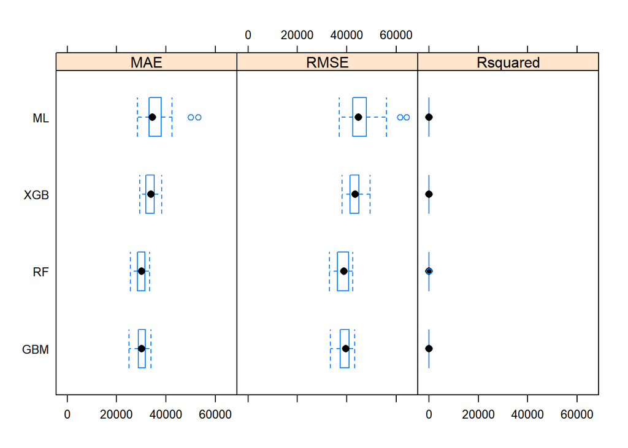

```r
# boxplots of results
bwplot(results)
```

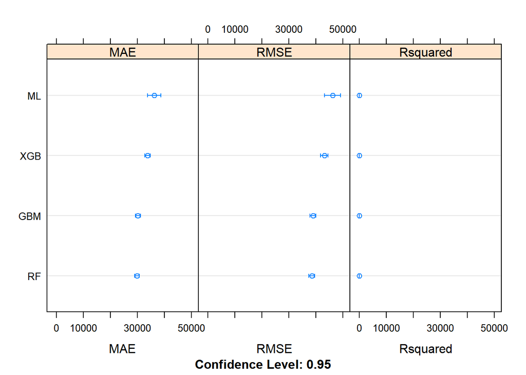

```r
# dot plots of results
dotplot(results)
```

```r
# lm
#modelo_lm<-  train(Qtd_o3 ~ .,data=data_o3_train %>% select(-data) ,method = "lm")
```

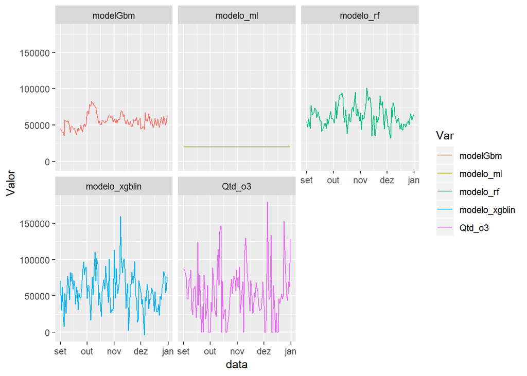

```r
#---- Plots previsao
Forecast = lapply(list(modelo_xgblin,
                       modelGbm,
                       #modelSvm,
                       modelo_rf,
                       modelo_ml
                       ),
                  predict, data_o3_test %>% select(-data,-Qtd_o3)) %>%
          data.frame();
colnames(Forecast)<-c('modelo_xgblin',
                      'modelGbm',
                     # 'modelSvm',
                      'modelo_rf',
                      'modelo_ml')
Data_pred<- data_o3_test %>% select(data,Qtd_o3) %>%
            cbind(Forecast) %>% gather(Var,Valor,-data)

Data_pred %>% ggplot(aes(data,Valor, col=Var))+geom_line()+facet_wrap(~Var)
```

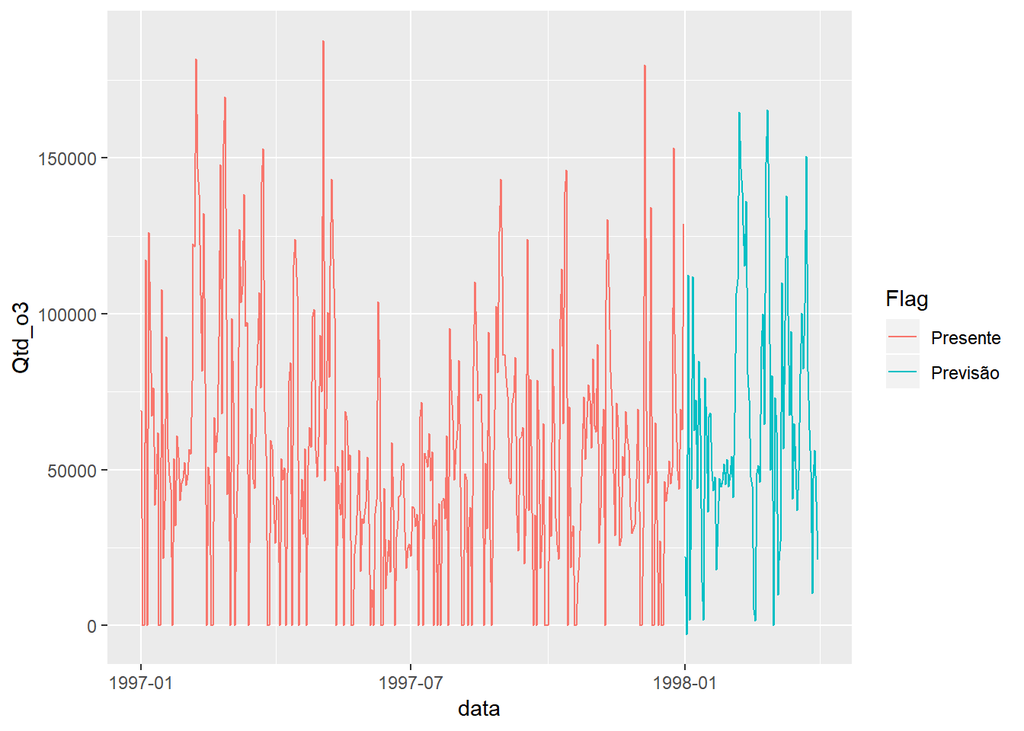

```r
#---- Previsao
forecast_2<- predict(modelo_xgblin,data_future) %>% data.frame()
colnames(forecast_2)<-c("Qtd_o3")
Data_pred<-
  data_future %>%
  cbind(forecast_2) %>%
  select(data,Qtd_o3)%>%
  rbind(data_o3) %>%
  mutate(Flag = if_else(data>max(data_o3$data),"Previsão","Presente"))



Data_pred %>% ggplot(aes(data,Qtd_o3, col=Flag))+geom_line()
```

Por final temos a previsão considerando o modelo XgbLinear.